# Housing & Schools Analysis

## Context

A small, private housing organization is looking to expand on opportunities in new neighborhoods. Although the organization cannot disclose much about their project, they would still like an outside opinion on housing market patterns in certain neighborhoods.

The organization has hired you as a consultant to analyze a subset of their data and provide recommendations for areas of potential growth. The organization has a mix of people with varying data science backgrounds. The ones who will be reading your report range from somewhat familiar with data science to completely unfamiliar with data science. They have asked you to make sure that your report is clear to all readers. The organization would also like an annotated copy of your R-code in case they need to re-run analyses.

## About the datasets

*housing.csv* - dataset of houses sold in 2019

- **neighborhood** – name of the neighborhood, indicator of a general area in the city
- **beds** – number of bedrooms in the unit
- **baths** – number of bathrooms in the unit
- **sqft** – unit square footage
- **lotsize** – unit’s lot size
- **year** – year that the unit was built
- **type** – unit type
- **levels** – how many floors are in the unit
- **cooling** – whether or not the unit has cooling
- **heating** – whether or not the unit has central heating
- **fireplace** – whether or not the unit has a fireplace
- **elementary** – unit’s assigned elementary school
- **middle** – unit’s assigned middle school
- **high** – unit’s assigned high school
- **soldprice** – selling price of the home

*schools.csv* – dataset of school rating

- **school** – name of the high school
- **size** – approximate student population size
- **rating** – school rating on a 1 to 10 scale

### Libraries

```r
library(stringr)
library(dplyr)
```

```r
library(ggplot2)
```

### Data Exploration and Data Cleaning

**housing.csv EXPLORATION**

```r
housing <-read.csv("housing.csv", header = T)
dim(housing)
```

```
## [1] 683  15
```

```r
summary(housing)
```

```
##  neighborhood            beds             baths             sqft
##  Length:683         Min.   :  1.000   Min.   : 1.000   Min.   : 536
##  Class :character   1st Qu.:  3.000   1st Qu.: 1.000   1st Qu.:1349
##  Mode  :character   Median :  4.000   Median : 1.500   Median :1955
##                     Mean   :  4.937   Mean   : 2.001   Mean   :2128
##                     3rd Qu.:  4.000   3rd Qu.: 2.500   3rd Qu.:2676
##                     Max.   :999.000   Max.   :25.000   Max.   :5265
##                                                        NA's   :2
##     lotsize            year          type              levels
##  Min.   :0.0700   Min.   :1495   Length:683         Length:683
##  1st Qu.:0.1600   1st Qu.:1961   Class :character   Class :character
##  Median :0.2400   Median :1978   Mode  :character   Mode  :character
##  Mean   :0.2889   Mean   :1977
##  3rd Qu.:0.3600   3rd Qu.:1997
##  Max.   :1.3000   Max.   :2111
##  NA's   :20
##    cooling            heating           fireplace          elementary
##  Length:683         Length:683         Length:683         Length:683
##  Class :character   Class :character   Class :character   Class :character
##  Mode  :character   Mode  :character   Mode  :character   Mode  :character
##
##
##
##
##     middle              high             soldprice
##  Length:683         Length:683         Min.   :    664
##  Class :character   Class :character   1st Qu.: 974500
##  Mode  :character   Mode  :character   Median :1267000
##                                        Mean   :1244858
##                                        3rd Qu.:1548000
##                                        Max.   :2393000
##
```

Let’s analyze this first summary of the *housing.csv* dataset, column by column: We can’t say much about the *neighborhood*, *type*, *levels*, *cooling*, *heating*, *fireplace*, *elementary*, *middle* and *high* columns, as the values are not categorized. The *beds* column takes most of its values between 1 and 4, but the maximum value is 999. You can therefore expect visible outliers. The same goes for the *baths* column, which takes most of its values between 1 and 2.5, yet has a maximum value of 25. The *sqft* values are very wide but not unlikely, ranging from 536 to 5265, with 50% of values being between 1349 and 2676. There are 2 NA’s. A few outliers are to be expected in the *lotsize* category, in addition to 20 NA’s. In the *year* category, it’s surprising that the minimum year is 1495 for a 1st quartile of 1961. This year is probably an outlier. Same for the 2111 value which can not be correct, obvisouly. The rest of the values seem correct. Finally, the *soldprice* column takes most of its values between 974500 and 1548000, with a minimum of 664 and a maximum of 2393000. The difference between min and Q1 is impressive, probably the result of an outlier.

Let’s check our guesses with simple boxplots:

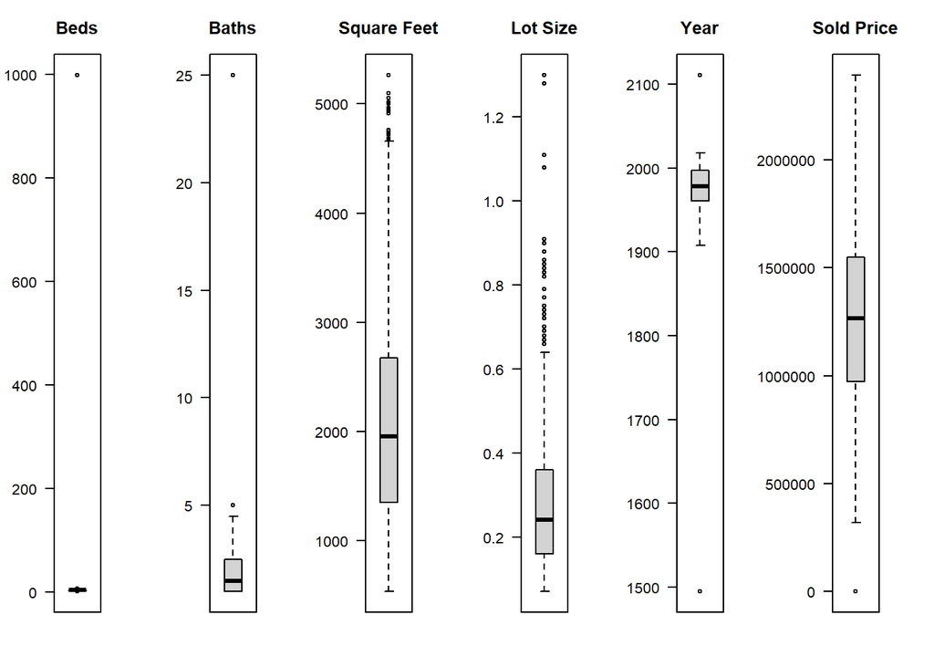

```r
par(mfrow = c(1, 6), mar = c(3, 3, 3, 3) + 0.1, las = 1)

boxplot(housing$beds, main="Beds")
boxplot(housing$baths, main="Baths")
boxplot(housing$sqft, main="Square Feet")
boxplot(housing$lotsize, main="Lot Size")
boxplot(housing$year, main="Year")
boxplot(housing$soldprice, main="Sold Price")
```

From the boxplots, we can deduce that the Max value of the *beds* category absolutely must be removed or readjusted, as it is the only outlier in this category, as must the *baths* category and its Max value of 25. The *sqft* category contains a few outliers at the top of the boxplot. The values remain fairly close, so their presence doesn’t seem to be a cause for concern. The *lotsize* category has many outliers in the upper part of the boxplot, so 4 are quite far apart. A readjustment may be in order. The *year* category has 2 extreme values: the minimum value of 1495 identified above, and the maximum value for 2111. We could delete or readjust these values. Finally, *soldprice* contains only one outlier, the value 664 mentionned earlier.

Before going further, let’s categorize the columns mentionned above:

```r
housing$neighborhood <- as.factor(housing$neighborhood)
housing$type <- as.factor(housing$type)
housing$levels <- as.integer(housing$levels)
housing$cooling <- as.factor(housing$cooling)
housing$heating <- as.factor(housing$heating)
housing$fireplace <- as.factor(housing$fireplace)
housing$elementary <- as.factor(housing$elementary)
housing$middle <- as.factor(housing$middle)
housing$high <- as.factor(housing$high)

summary(housing)
```

```
##   neighborhood      beds             baths             sqft
##  Orange :141   Min.   :  1.000   Min.   : 1.000   Min.   : 536
##  Blue   :136   1st Qu.:  3.000   1st Qu.: 1.000   1st Qu.:1349
##  Red    :116   Median :  4.000   Median : 1.500   Median :1955
##  Green  :102   Mean   :  4.937   Mean   : 2.001   Mean   :2128
##  Yellow : 68   3rd Qu.:  4.000   3rd Qu.: 2.500   3rd Qu.:2676
##  Silver : 66   Max.   :999.000   Max.   :25.000   Max.   :5265
##  (Other): 54                                      NA's   :2
##     lotsize            year                      type         levels
##  Min.   :0.0700   Min.   :1495   condo             :147   Min.   :1.000
##  1st Qu.:0.1600   1st Qu.:1961   condominium       :  3   1st Qu.:1.000
##  Median :0.2400   Median :1978   multi-family home : 69   Median :1.000
##  Mean   :0.2889   Mean   :1977   single-family home:333   Mean   :1.377
##  3rd Qu.:0.3600   3rd Qu.:1997   town house        :  2   3rd Qu.:2.000
##  Max.   :1.3000   Max.   :2111   townhouse         :129   Max.   :2.000
##  NA's   :20                                               NA's   :6
##  cooling   heating   fireplace               elementary             middle
##     :  7      :  7      :  6   Leopard Elementary : 48   Wolf Middle   : 63
##  No :454   No :530   No :459   Kodkod Elementary  : 37   Fox Middle    : 57
##  Yes:222   Yes:146   Yes:218   Savannah Elementary: 37   Hound Middle  : 56
##                                Puma Elementary    : 36   Coyote Middle : 53
##                                Ocicat Elementary  : 35   Sloth Middle  : 51
##                                Cheetah Elementary : 34   Raccoon Middle: 48
##                                (Other)            :456   (Other)       :355
##             high       soldprice
##  Channel High : 70   Min.   :    664
##  Delta High   : 66   1st Qu.: 974500
##  Alpine High  : 58   Median :1267000
##  Crevasse High: 58   Mean   :1244858
##  Glacier High : 53   3rd Qu.:1548000
##  Ravine High  : 52   Max.   :2393000
##  (Other)      :326
```

```r
table(housing$neighborhood)
```

```
##
##   Blue   Gold  Green Orange Purple    Red Silver Yellow
##    136     51    102    141      3    116     66     68
```

```r
table(housing$type)
```

```
##
##              condo        condominium  multi-family home single-family home
##                147                  3                 69                333
##         town house          townhouse
##                  2                129
```

```r
table(housing$elementary)
```

```
##
##   Birman Elementary   Bobcat Elementary  Caracal Elementary  Cheetah Elementary
##                  32                  33                  32                  34
##   Cougar Elementary   Jaguar Elementary   Kodkod Elementary    Korat Elementary
##                  24                  33                  37                  31
##  Leopard Elementary     Lion Elementary     Lynx Elementary   Margay Elementary
##                  48                  24                  25                  23
## Munchkin Elementary   Ocelot Elementary   Ocicat Elementary  Oncilla Elementary
##                  19                  21                  35                  23
##  Panther Elementary     Puma Elementary Savannah Elementary   Serval Elementary
##                  27                  36                  37                  20
##   Sphynx Elementary    Tiger Elementary  Wildcat Elementary
##                  33                  27                  29
```

```r
table(housing$middle)
```

```
##
##    Bear Middle  Coyote Middle  Culpeo Middle   Dhole Middle Epicyon Middle
##             37             53             35             41             42
##     Fox Middle   Hound Middle   Husky Middle  Jackal Middle   Panda Middle
##             57             56             33             43             32
## Raccoon Middle   Sloth Middle Vulpini Middle    Wolf Middle   Zorro Middle
##             48             51             46             63             46
```

```r
table(housing$high)
```

```
##
##    Alpine High     Atlas High Avalanche High  Blizzard High   Channel High
##             58             42             51             33             70
##  Crevasse High     Delta High   Glacier High   Moraine High  Mountain High
##             58             66             53             33             36
##    Ravine High     River High    Summit High    Valley High
##             52             50             49             32
```

Now that the columns neighborhood, type, levels, cooling, heating, fireplace, elementary, middle and high are categorized, we can analyze them:

*neighborhood* is categorized by color and there are no NA’s to report. However, we note that the purple category is under-represented: it contains 3 values, compared with 141 for orange, for example. *type* contains duplicate. Indeed, condo is a short for condominium, et town house is the same as townhouse without space. *levels* appears well-balanced, but has 6 NA’s. *cooling*, *heating* and *fireplace* have 7, 7 and 6 NA’s respectively. For the *elementary*, *middle* and *high* categories, there are no missing values. What’s more, the values are well distributed overall.

Let’s keep in mind that we have a dataset of 683 rows, so deleting some rows containing NA should not affect the results of our dataset. However, let’s find a way to keep as many values as possible.

**housing.csv CLEANING**

Let’s begin the cleaning section by looking at the duplicate :

```r
# Trim leading and trailing spaces in the cooling, heating and fireplace column
housing$type <- str_trim(housing$type)

# Change value
housing$type[housing$type == "condominium"] <- "condo"
housing$type[housing$type == "town house"] <- "townhouse"

housing$type <- as.factor(housing$type)

table(housing$type)
```

```
##
##              condo  multi-family home single-family home          townhouse
##                150                 69                333                131
```

Now, let’s take a look at the outliers:

- **999 beds?**

```r
housing[housing$beds == 999, ]
```

|  | neighborhood | beds | baths | sqft | lotsize | year | type | levels | cooling | heating | fireplace | elementary | middle | high | soldprice |
| --- | --- | --- | --- | --- | --- | --- | --- | --- | --- | --- | --- | --- | --- | --- | --- |
| 189 | Orange | 999 | 1 | 753 | NA | 1957 | townhouse | 1 | No | No | No | Lion Elementary | Fox Middle | Glacier High | 647000 |

999 was obviously a mistake because there is only 1 bath and the house has 753 square feet, which is pretty small to indeed contain 999 bedrooms. Let’s look at similar house :

```r
housing[housing$sqft == 753, ]
```

|  | neighborhood | beds | baths | sqft | lotsize | year | type | levels | cooling | heating | fireplace | elementary | middle | high | soldprice |
| --- | --- | --- | --- | --- | --- | --- | --- | --- | --- | --- | --- | --- | --- | --- | --- |
| NA | NA | NA | NA | NA | NA | NA | NA | NA | NA | NA | NA | NA | NA | NA | NA |
| NA.1 | NA | NA | NA | NA | NA | NA | NA | NA | NA | NA | NA | NA | NA | NA | NA |
| 186 | Orange | 1 | 1 | 753 | 0.17 | 1952 | townhouse | 1 | No | No | Yes | Leopard Elementary | Dhole Middle | Atlas High | 636000 |
| 189 | Orange | 999 | 1 | 753 | NA | 1957 | townhouse | 1 | No | No | No | Lion Elementary | Fox Middle | Glacier High | 647000 |
| 209 | Orange | 1 | 1 | 753 | 0.13 | 2010 | condo | 1 | Yes | Yes | No | Jaguar Elementary | Fox Middle | Glacier High | 664 |
| 388 | Green | 1 | 1 | 753 | 0.11 | 1994 | multi-family home | 1 | Yes | Yes | No | Panther Elementary | Hound Middle | Ravine High | 1212000 |

In comparison with similar houses, 999 bedrooms can be changed into a 1 bedroom house.

```r
housing$beds[housing$beds == 999] <- 1
housing[189, ]
```

|  | neighborhood | beds | baths | sqft | lotsize | year | type | levels | cooling | heating | fireplace | elementary | middle | high | soldprice |
| --- | --- | --- | --- | --- | --- | --- | --- | --- | --- | --- | --- | --- | --- | --- | --- |
| 189 | Orange | 1 | 1 | 753 | NA | 1957 | townhouse | 1 | No | No | No | Lion Elementary | Fox Middle | Glacier High | 647000 |

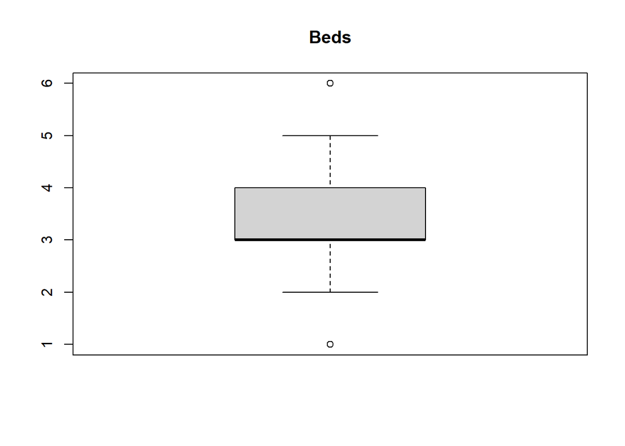

```r
boxplot(housing$beds, main="Beds")
```

```r
housing[housing$beds == 6, ]
```

|  | neighborhood | beds | baths | sqft | lotsize | year | type | levels | cooling | heating | fireplace | elementary | middle | high | soldprice |
| --- | --- | --- | --- | --- | --- | --- | --- | --- | --- | --- | --- | --- | --- | --- | --- |
| 1 | Red | 6 | 4.0 | 4233 | 0.88 | 1926 | single-family home | 1 | No | No | No | Cougar Elementary | Wolf Middle | Alpine High | 1289000 |
| 4 | Red | 6 | 3.5 | 4454 | 0.43 | 1938 | single-family home | 2 | No | No | Yes | Lynx Elementary | Coyote Middle | Crevasse High | 1246000 |
| 9 | Red | 6 | 3.5 | 3245 | 0.41 | 1984 | townhouse | 1 | Yes | Yes | No | Lynx Elementary | Coyote Middle | Alpine High | 1035000 |
| 13 | Red | 6 | 3.0 | 4764 | 0.91 | 1925 | single-family home | 1 | No | No | Yes | Bobcat Elementary | Coyote Middle | Crevasse High | 1266000 |
| 28 | Red | 6 | 3.0 | 3151 | 0.20 | 1980 | single-family home | 2 | Yes | No | Yes | Bobcat Elementary | Wolf Middle | Alpine High | 1618000 |
| 49 | Red | 6 | 4.0 | 3829 | 0.27 | 1979 | condo | 2 | Yes | No | No | Lynx Elementary | Wolf Middle | Crevasse High | 787000 |
| 52 | Red | 6 | 4.5 | 4757 | 0.55 | 1966 | single-family home | 1 | No | No | No | Bobcat Elementary | Coyote Middle | Alpine High | 1478000 |
| 71 | Red | 6 | 5.0 | 3362 | 0.35 | 1949 | single-family home | 2 | No | No | No | Cougar Elementary | Coyote Middle | Alpine High | 1612000 |
| 75 | Red | 6 | 3.5 | 4005 | 0.61 | 1933 | townhouse | 1 | No | No | Yes | Bobcat Elementary | Wolf Middle | Crevasse High | 897000 |
| 91 | Red | 6 | 5.0 | 4684 | 0.28 | 1934 | single-family home | 2 | No | No | Yes | Bobcat Elementary | Coyote Middle | Crevasse High | 1421000 |

[output cut: 78 more lines]

```r
housing[housing$beds == 1, ]
```

|  | neighborhood | beds | baths | sqft | lotsize | year | type | levels | cooling | heating | fireplace | elementary | middle | high | soldprice |
| --- | --- | --- | --- | --- | --- | --- | --- | --- | --- | --- | --- | --- | --- | --- | --- |
| 2 | Red | 1 | 1 | 748 | 0.11 | 1985 | condo | 1 | No | No | No | Bobcat Elementary | Wolf Middle | Alpine High | 499000 |
| 22 | Red | 1 | 1 | 536 | 0.12 | 1977 | townhouse | 1 | Yes | No | No | Cheetah Elementary | Coyote Middle | Crevasse High | 573000 |
| 24 | Red | 1 | 1 | 781 | 0.10 | 1975 | single-family home | 1 | Yes | No | No | Cheetah Elementary | Coyote Middle | Alpine High | 1112000 |
| 25 | Red | 1 | 1 | 779 | 0.14 | 1940 | townhouse | 1 | No | No | No | Cougar Elementary | Wolf Middle | Crevasse High | 458000 |
| 36 | Red | 1 | 1 | NA | 0.15 | 1943 | condo | 1 | No | No | No | Lynx Elementary | Wolf Middle | Crevasse High | 321000 |
| 43 | Red | 1 | 1 | 654 | 0.19 | 1936 | townhouse | 1 | No | No | Yes | Bobcat Elementary | Wolf Middle | Alpine High | 512000 |
| 45 | Red | 1 | 1 | 749 | 0.14 | 1946 | single-family home | NA | No | No | No | Lynx Elementary | Wolf Middle | Alpine High | 1009000 |
| 53 | Red | 1 | 1 | 717 | 0.16 | 1939 | townhouse | 1 | No | No | No | Cheetah Elementary | Wolf Middle | Crevasse High | 446000 |
| 65 | Red | 1 | 1 | 648 | 0.19 | 1974 | townhouse | 1 | Yes | No | No | Bobcat Elementary | Wolf Middle | Crevasse High | 457000 |
| 83 | Red | 1 | 1 | 673 | 0.13 | 1971 | condo | 1 | Yes | No | No | Cheetah Elementary | Coyote Middle | Crevasse High | 426000 |

[output cut: 82 more lines]

88 houses contain 6 bedrooms, and 92 contains 1 bedroom. It is not an isolated cases so we can let it this way.

- **25 baths?**

```r
housing[housing$baths == 25, ]
```

|  | neighborhood | beds | baths | sqft | lotsize | year | type | levels | cooling | heating | fireplace | elementary | middle | high | soldprice |
| --- | --- | --- | --- | --- | --- | --- | --- | --- | --- | --- | --- | --- | --- | --- | --- |
| 520 | Blue | 4 | 25 | 2560 | 0.37 | 2009 | single-family home | 1 | No | Yes | No | Caracal Elementary | Epicyon Middle | Channel High | 1456000 |

```r
housing[housing$beds == 4 & housing$sqft >= 2450 & housing$sqft <= 2650 & housing$type == "single-family home" & housing$levels == 1, ]
```

|  | neighborhood | beds | baths | sqft | lotsize | year | type | levels | cooling | heating | fireplace | elementary | middle | high | soldprice |
| --- | --- | --- | --- | --- | --- | --- | --- | --- | --- | --- | --- | --- | --- | --- | --- |
| 31 | Red | 4 | 2.0 | 2636 | 0.34 | 1935 | single-family home | 1 | No | No | Yes | Cougar Elementary | Wolf Middle | Crevasse High | 1332000 |
| 34 | Red | 4 | 1.0 | 2603 | 0.75 | 1982 | single-family home | 1 | No | Yes | Yes | Cougar Elementary | Coyote Middle | Crevasse High | 1339000 |
| 66 | Red | 4 | 3.0 | 2493 | 0.34 | 1963 | single-family home | 1 | No | No | No | Bobcat Elementary | Wolf Middle | Alpine High | 1367000 |
| 347 | Green | 4 | 1.5 | 2646 | 0.67 | 2003 | single-family home | 1 | No | Yes | Yes | Panther Elementary | Hound Middle | River High | 1868000 |
| 385 | Green | 4 | 2.5 | 2540 | 0.29 | 1980 | single-family home | 1 | No | No | No | Panther Elementary | Vulpini Middle | Ravine High | 1468000 |
| 407 | Green | 4 | 2.0 | 2497 | 0.32 | 1985 | single-family home | 1 | Yes | No | No | Margay Elementary | Vulpini Middle | River High | 1748000 |
| 465 | Blue | 4 | 1.0 | 2454 | 0.35 | 1962 | single-family home | 1 | No | No | No | Sphynx Elementary | Zorro Middle | Channel High | 1232000 |
| 520 | Blue | 4 | 25.0 | 2560 | 0.37 | 2009 | single-family home | 1 | No | Yes | No | Caracal Elementary | Epicyon Middle | Channel High | 1456000 |
| 667 | Silver | 4 | 1.0 | 2503 | 0.29 | 1957 | single-family home | 1 | No | No | Yes | Korat Elementary | Bear Middle | Moraine High | 1458000 |

In comparison with similar houses and considering this outlier as a typing mistake, 25 bathrooms can be changed into a 2.5 bathroom house.

```r
housing$baths[housing$baths == 25] <- 2.5
housing[520, ]
```

|  | neighborhood | beds | baths | sqft | lotsize | year | type | levels | cooling | heating | fireplace | elementary | middle | high | soldprice |
| --- | --- | --- | --- | --- | --- | --- | --- | --- | --- | --- | --- | --- | --- | --- | --- |
| 520 | Blue | 4 | 2.5 | 2560 | 0.37 | 2009 | single-family home | 1 | No | Yes | No | Caracal Elementary | Epicyon Middle | Channel High | 1456000 |

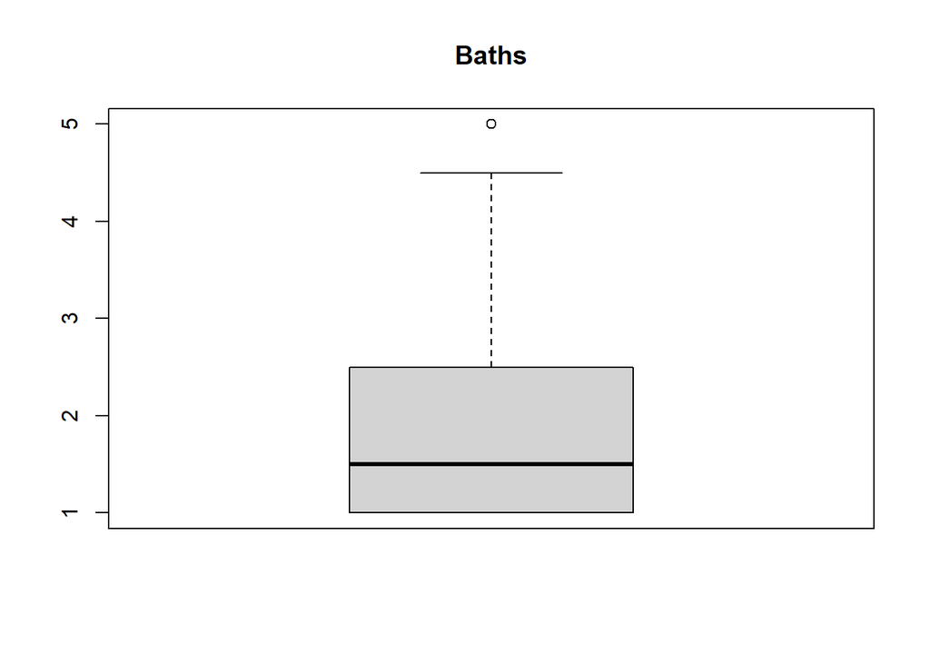

```r
boxplot(housing$baths, main="Baths")
```

There is still what seem to be an outlier with value equal 5.

```r
housing[housing$baths == 5, ]
```

|  | neighborhood | beds | baths | sqft | lotsize | year | type | levels | cooling | heating | fireplace | elementary | middle | high | soldprice |
| --- | --- | --- | --- | --- | --- | --- | --- | --- | --- | --- | --- | --- | --- | --- | --- |
| 71 | Red | 6 | 5 | 3362 | 0.35 | 1949 | single-family home | 2 | No | No | No | Cougar Elementary | Coyote Middle | Alpine High | 1612000 |
| 91 | Red | 6 | 5 | 4684 | 0.28 | 1934 | single-family home | 2 | No | No | Yes | Bobcat Elementary | Coyote Middle | Crevasse High | 1421000 |
| 100 | Red | 6 | 5 | 4255 | 0.38 | 1964 | townhouse | 2 | No | No | Yes | Bobcat Elementary | Wolf Middle | Alpine High | 1031000 |
| 101 | Red | 6 | 5 | 4538 | 0.74 | 1953 | single-family home | 1 | No | No | Yes | Cougar Elementary | Wolf Middle | Alpine High | 1487000 |
| 103 | Red | 6 | 5 | 3257 | 0.83 | 1966 | single-family home | 1 | No | No | Yes | Bobcat Elementary | Wolf Middle | Alpine High | 1430000 |
| 185 | Orange | 6 | 5 | 4375 | 0.50 | 1952 | single-family home | 1 | No | No | Yes | Leopard Elementary | Fox Middle | Atlas High | 1592000 |
| 191 | Orange | 6 | 5 | 3773 | 0.72 | 1949 | townhouse | 1 | No | No | No | Puma Elementary | Fox Middle | Glacier High | 968000 |
| 227 | Orange | 6 | 5 | 4436 | 0.28 | 1983 | townhouse | 2 | No | No | No | Lion Elementary | Fox Middle | Summit High | 1200000 |
| 234 | Orange | 6 | 5 | 3198 | 0.46 | 1950 | townhouse | 1 | No | No | Yes | Puma Elementary | Fox Middle | Atlas High | 1008000 |
| 243 | Orange | 6 | 5 | 3934 | 0.90 | 1977 | single-family home | 1 | Yes | No | No | Puma Elementary | Jackal Middle | Glacier High | 1643000 |

[output cut: 7 more lines]

17 houses contain 5 bathrooms. It is not an isolated case so we can let it this way.

- **year 1495?**

```r
housing[housing$year == 1495, ]
```

|  | neighborhood | beds | baths | sqft | lotsize | year | type | levels | cooling | heating | fireplace | elementary | middle | high | soldprice |
| --- | --- | --- | --- | --- | --- | --- | --- | --- | --- | --- | --- | --- | --- | --- | --- |
| 677 | Silver | 1 | 1 | 824 | 0.1 | 1495 | townhouse | 1 | No | No | No | Ocicat Elementary | Panda Middle | Moraine High | 832000 |

```r
housing[housing$beds == 1 & housing$baths == 1 & housing$sqft >= 750 & housing$sqft <= 850 & housing$type == "townhouse" & housing$levels == 1, ]
```

|  | neighborhood | beds | baths | sqft | lotsize | year | type | levels | cooling | heating | fireplace | elementary | middle | high | soldprice |
| --- | --- | --- | --- | --- | --- | --- | --- | --- | --- | --- | --- | --- | --- | --- | --- |
| 25 | Red | 1 | 1 | 779 | 0.14 | 1940 | townhouse | 1 | No | No | No | Cougar Elementary | Wolf Middle | Crevasse High | 458000 |
| 186 | Orange | 1 | 1 | 753 | 0.17 | 1952 | townhouse | 1 | No | No | Yes | Leopard Elementary | Dhole Middle | Atlas High | 636000 |
| 189 | Orange | 1 | 1 | 753 | NA | 1957 | townhouse | 1 | No | No | No | Lion Elementary | Fox Middle | Glacier High | 647000 |
| 306 | Yellow | 1 | 1 | 752 | 0.14 | 2001 | townhouse | 1 | Yes | No | No | Ocelot Elementary | Husky Middle | Mountain High | 1014000 |
| 311 | Yellow | 1 | 1 | 770 | 0.14 | 1974 | townhouse | 1 | No | No | Yes | Tiger Elementary | Husky Middle | Mountain High | 844000 |
| 673 | Silver | 1 | 1 | 764 | 0.13 | 1950 | townhouse | 1 | No | No | Yes | Ocicat Elementary | Panda Middle | Moraine High | 896000 |
| 677 | Silver | 1 | 1 | 824 | 0.10 | 1495 | townhouse | 1 | No | No | No | Ocicat Elementary | Panda Middle | Moraine High | 832000 |

In comparison with similar houses, We can suppose that 1495 was actually an error made while typing the number. Therefore, we turn 1495 into 1945.

```r
housing$year[housing$year == 1495] <- 1945
housing[677, ]
```

|  | neighborhood | beds | baths | sqft | lotsize | year | type | levels | cooling | heating | fireplace | elementary | middle | high | soldprice |
| --- | --- | --- | --- | --- | --- | --- | --- | --- | --- | --- | --- | --- | --- | --- | --- |
| 677 | Silver | 1 | 1 | 824 | 0.1 | 1945 | townhouse | 1 | No | No | No | Ocicat Elementary | Panda Middle | Moraine High | 832000 |

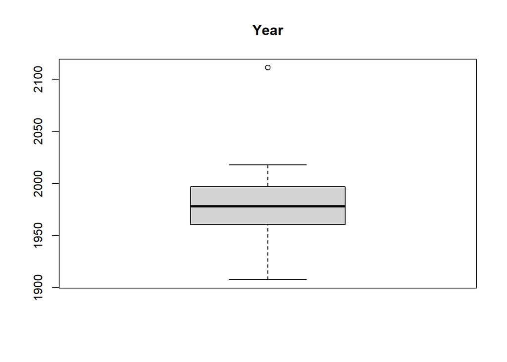

```r
boxplot(housing$year, main="Year")
```

- **year 2111?**

```r
housing[housing$year == 2111, ]
```

|  | neighborhood | beds | baths | sqft | lotsize | year | type | levels | cooling | heating | fireplace | elementary | middle | high | soldprice |
| --- | --- | --- | --- | --- | --- | --- | --- | --- | --- | --- | --- | --- | --- | --- | --- |
| 193 | Orange | 4 | 1.5 | 2822 | 0.29 | 2111 | single-family home | 2 | Yes | No | No | Leopard Elementary | Jackal Middle | Glacier High | 1393000 |

2111 is probably a mistake made while writing the date. Let’s replace this value by 2011 which seem to be more reasonable.

```r
housing$year[housing$year == 2111] <- 2011
housing[193, ]
```

|  | neighborhood | beds | baths | sqft | lotsize | year | type | levels | cooling | heating | fireplace | elementary | middle | high | soldprice |
| --- | --- | --- | --- | --- | --- | --- | --- | --- | --- | --- | --- | --- | --- | --- | --- |
| 193 | Orange | 4 | 1.5 | 2822 | 0.29 | 2011 | single-family home | 2 | Yes | No | No | Leopard Elementary | Jackal Middle | Glacier High | 1393000 |

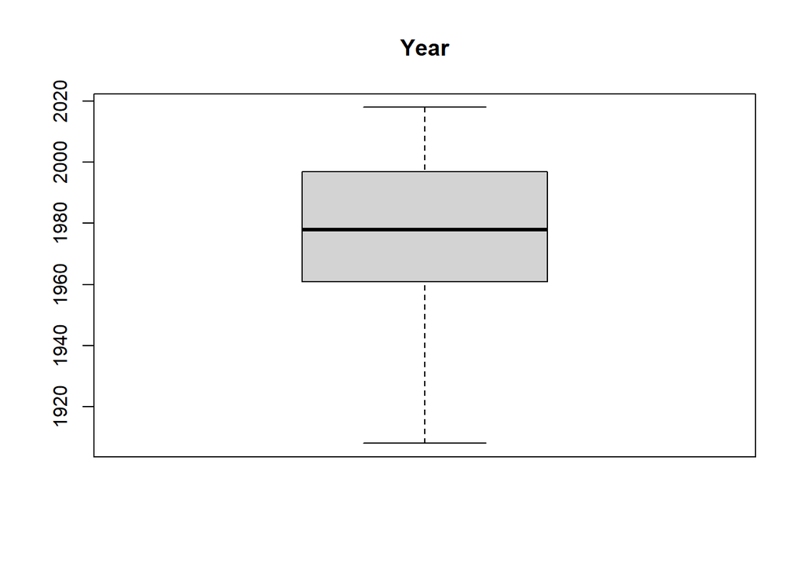

```r
boxplot(housing$year, main="Year")
```

- **Soldprice equal to 664?**

```r
housing[housing$soldprice == 664, ]
```

|  | neighborhood | beds | baths | sqft | lotsize | year | type | levels | cooling | heating | fireplace | elementary | middle | high | soldprice |
| --- | --- | --- | --- | --- | --- | --- | --- | --- | --- | --- | --- | --- | --- | --- | --- |
| 209 | Orange | 1 | 1 | 753 | 0.13 | 2010 | condo | 1 | Yes | Yes | No | Jaguar Elementary | Fox Middle | Glacier High | 664 |

```r
housing[housing$beds == 1 & housing$baths == 1 & housing$sqft >= 700 & housing$sqft <= 800 & housing$type == "condo" & housing$levels == 1 & housing$neighborhood == "Orange", ]
```

|  | neighborhood | beds | baths | sqft | lotsize | year | type | levels | cooling | heating | fireplace | elementary | middle | high | soldprice |
| --- | --- | --- | --- | --- | --- | --- | --- | --- | --- | --- | --- | --- | --- | --- | --- |
| 175 | Orange | 1 | 1 | 797 | 0.10 | 1964 | condo | 1 | No | No | No | Leopard Elementary | Jackal Middle | Glacier High | 512000 |
| 209 | Orange | 1 | 1 | 753 | 0.13 | 2010 | condo | 1 | Yes | Yes | No | Jaguar Elementary | Fox Middle | Glacier High | 664 |
| 235 | Orange | 1 | 1 | 785 | 0.20 | 1965 | condo | 1 | No | No | No | Leopard Elementary | Jackal Middle | Atlas High | 423000 |

In comparison with similar houses in the same neighborhood, soldprice should be between 423000 and 512000 or above, especially that this house is newer than the other 2 and it has cooling and heating. Therefore, price is probably missing zeros.

```r
housing$soldprice[housing$soldprice == 664] <- 664000
housing[209, ]
```

|  | neighborhood | beds | baths | sqft | lotsize | year | type | levels | cooling | heating | fireplace | elementary | middle | high | soldprice |
| --- | --- | --- | --- | --- | --- | --- | --- | --- | --- | --- | --- | --- | --- | --- | --- |
| 209 | Orange | 1 | 1 | 753 | 0.13 | 2010 | condo | 1 | Yes | Yes | No | Jaguar Elementary | Fox Middle | Glacier High | 664000 |

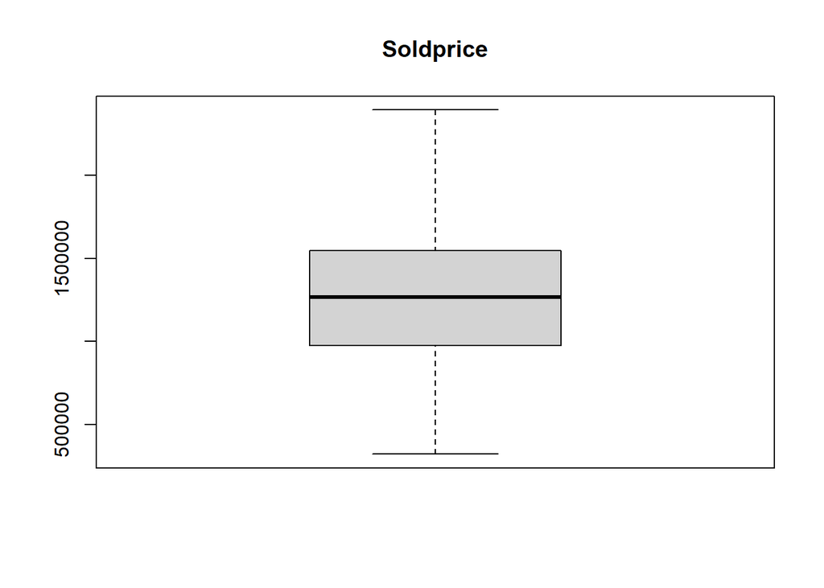

```r
boxplot(housing$soldprice, main="Soldprice")
```

```r
summary(housing)
```

```
##   neighborhood      beds           baths            sqft         lotsize
##  Orange :141   Min.   :1.000   Min.   :1.000   Min.   : 536   Min.   :0.0700
##  Blue   :136   1st Qu.:3.000   1st Qu.:1.000   1st Qu.:1349   1st Qu.:0.1600
##  Red    :116   Median :3.000   Median :1.500   Median :1955   Median :0.2400
##  Green  :102   Mean   :3.476   Mean   :1.969   Mean   :2128   Mean   :0.2889
##  Yellow : 68   3rd Qu.:4.000   3rd Qu.:2.500   3rd Qu.:2676   3rd Qu.:0.3600
##  Silver : 66   Max.   :6.000   Max.   :5.000   Max.   :5265   Max.   :1.3000
##  (Other): 54                                   NA's   :2      NA's   :20
##       year                      type         levels      cooling   heating
##  Min.   :1908   condo             :150   Min.   :1.000      :  7      :  7
##  1st Qu.:1961   multi-family home : 69   1st Qu.:1.000   No :454   No :530
##  Median :1978   single-family home:333   Median :1.000   Yes:222   Yes:146
##  Mean   :1978   townhouse         :131   Mean   :1.377
##  3rd Qu.:1997                            3rd Qu.:2.000
##  Max.   :2018                            Max.   :2.000
##                                          NA's   :6
##  fireplace               elementary             middle               high
##     :  6   Leopard Elementary : 48   Wolf Middle   : 63   Channel High : 70
##  No :459   Kodkod Elementary  : 37   Fox Middle    : 57   Delta High   : 66
##  Yes:218   Savannah Elementary: 37   Hound Middle  : 56   Alpine High  : 58
##            Puma Elementary    : 36   Coyote Middle : 53   Crevasse High: 58
##            Ocicat Elementary  : 35   Sloth Middle  : 51   Glacier High : 53
##            Cheetah Elementary : 34   Raccoon Middle: 48   Ravine High  : 52
##            (Other)            :456   (Other)       :355   (Other)      :326
##    soldprice
##  Min.   : 321000
##  1st Qu.: 974500
##  Median :1267000
##  Mean   :1245829
##  3rd Qu.:1548000
##  Max.   :2393000
##
```

**Missing values**

Now, let’s change the empty space of cooling, heating and fireplace in NA’s value:

```r
# Trim leading and trailing spaces in the cooling, heating and fireplace column
housing$cooling <- str_trim(housing$cooling)
housing$heating <- str_trim(housing$heating)
housing$fireplace <- str_trim(housing$fireplace)

# Replace empty strings with NA
housing$cooling[housing$cooling == ""] <- NA
housing$heating[housing$heating == ""] <- NA
housing$fireplace[housing$fireplace == ""] <- NA

# Replace Yes by 1 and No by 0
housing$cooling <- ifelse(housing$cooling == "Yes", 1,
                                      ifelse(housing$cooling == "No", 0, NA))
housing$heating <- ifelse(housing$heating == "Yes", 1,
                                      ifelse(housing$heating == "No", 0, NA))
housing$fireplace <- ifelse(housing$fireplace == "Yes", 1,
                                          ifelse(housing$fireplace == "No", 0, NA))
```

```r
summary(housing)
```

```
##   neighborhood      beds           baths            sqft         lotsize
##  Orange :141   Min.   :1.000   Min.   :1.000   Min.   : 536   Min.   :0.0700
##  Blue   :136   1st Qu.:3.000   1st Qu.:1.000   1st Qu.:1349   1st Qu.:0.1600
##  Red    :116   Median :3.000   Median :1.500   Median :1955   Median :0.2400
##  Green  :102   Mean   :3.476   Mean   :1.969   Mean   :2128   Mean   :0.2889
##  Yellow : 68   3rd Qu.:4.000   3rd Qu.:2.500   3rd Qu.:2676   3rd Qu.:0.3600
##  Silver : 66   Max.   :6.000   Max.   :5.000   Max.   :5265   Max.   :1.3000
##  (Other): 54                                   NA's   :2      NA's   :20
##       year                      type         levels         cooling
##  Min.   :1908   condo             :150   Min.   :1.000   Min.   :0.0000
##  1st Qu.:1961   multi-family home : 69   1st Qu.:1.000   1st Qu.:0.0000
##  Median :1978   single-family home:333   Median :1.000   Median :0.0000
##  Mean   :1978   townhouse         :131   Mean   :1.377   Mean   :0.3284
##  3rd Qu.:1997                            3rd Qu.:2.000   3rd Qu.:1.0000
##  Max.   :2018                            Max.   :2.000   Max.   :1.0000
##                                          NA's   :6       NA's   :7
##     heating        fireplace                   elementary             middle
##  Min.   :0.000   Min.   :0.000   Leopard Elementary : 48   Wolf Middle   : 63
##  1st Qu.:0.000   1st Qu.:0.000   Kodkod Elementary  : 37   Fox Middle    : 57
##  Median :0.000   Median :0.000   Savannah Elementary: 37   Hound Middle  : 56
##  Mean   :0.216   Mean   :0.322   Puma Elementary    : 36   Coyote Middle : 53
##  3rd Qu.:0.000   3rd Qu.:1.000   Ocicat Elementary  : 35   Sloth Middle  : 51
##  Max.   :1.000   Max.   :1.000   Cheetah Elementary : 34   Raccoon Middle: 48
##  NA's   :7       NA's   :6       (Other)            :456   (Other)       :355
##             high       soldprice
##  Channel High : 70   Min.   : 321000
##  Delta High   : 66   1st Qu.: 974500
##  Alpine High  : 58   Median :1267000
##  Crevasse High: 58   Mean   :1245829
##  Glacier High : 53   3rd Qu.:1548000
##  Ravine High  : 52   Max.   :2393000
##  (Other)      :326
```

Finally, we can take care of the missing values.

- **NA’s in sqft**

```r
# Use of all columns without NA's
msqft <- lm(sqft~neighborhood+beds+baths+year+type+elementary+middle+high+soldprice, data = housing)

housing[is.na(housing$sqft),] # rows 36 and 88
```

|  | neighborhood | beds | baths | sqft | lotsize | year | type | levels | cooling | heating | fireplace | elementary | middle | high | soldprice |
| --- | --- | --- | --- | --- | --- | --- | --- | --- | --- | --- | --- | --- | --- | --- | --- |
| 36 | Red | 1 | 1 | NA | 0.15 | 1943 | condo | 1 | 0 | 0 | 0 | Lynx Elementary | Wolf Middle | Crevasse High | 321000 |
| 88 | Red | 1 | 1 | NA | 0.10 | 1977 | single-family home | 1 | 1 | 0 | 0 | Cheetah Elementary | Coyote Middle | Alpine High | 1190000 |

```r
housing$sqft[is.na(housing$sqft)] <- round(predict(msqft, list(
    neighborhood = housing$neighborhood[is.na(housing$sqft)],
    beds = housing$beds[is.na(housing$sqft)],
    baths = housing$baths[is.na(housing$sqft)],
    year = housing$year[is.na(housing$sqft)],
    type = housing$type[is.na(housing$sqft)],
    elementary = housing$elementary[is.na(housing$sqft)],
    middle = housing$middle[is.na(housing$sqft)],
    high = housing$high[is.na(housing$sqft)],
    soldprice = housing$soldprice[is.na(housing$sqft)]
    )), 0)

housing[36, ]
```

|  | neighborhood | beds | baths | sqft | lotsize | year | type | levels | cooling | heating | fireplace | elementary | middle | high | soldprice |
| --- | --- | --- | --- | --- | --- | --- | --- | --- | --- | --- | --- | --- | --- | --- | --- |
| 36 | Red | 1 | 1 | 440 | 0.15 | 1943 | condo | 1 | 0 | 0 | 0 | Lynx Elementary | Wolf Middle | Crevasse High | 321000 |

```r
housing[88, ]
```

|  | neighborhood | beds | baths | sqft | lotsize | year | type | levels | cooling | heating | fireplace | elementary | middle | high | soldprice |
| --- | --- | --- | --- | --- | --- | --- | --- | --- | --- | --- | --- | --- | --- | --- | --- |
| 88 | Red | 1 | 1 | 540 | 0.1 | 1977 | single-family home | 1 | 1 | 0 | 0 | Cheetah Elementary | Coyote Middle | Alpine High | 1190000 |

- **NA’s in lotsize**

```r
# Use of all columns without NA's
mlotsize <- lm(lotsize~neighborhood+beds+baths+year+type+elementary+middle+high+soldprice, data = housing)

housing[is.na(housing$lotsize),] # 20 rows
```

|  | neighborhood | beds | baths | sqft | lotsize | year | type | levels | cooling | heating | fireplace | elementary | middle | high | soldprice |
| --- | --- | --- | --- | --- | --- | --- | --- | --- | --- | --- | --- | --- | --- | --- | --- |
| 33 | Red | 4 | 3.0 | 2206 | NA | 1980 | single-family home | 2 | 0 | 0 | 0 | Lynx Elementary | Coyote Middle | Alpine High | 1223000 |
| 61 | Red | 4 | 1.0 | 2848 | NA | 1957 | single-family home | 2 | 0 | 0 | 0 | Cheetah Elementary | Wolf Middle | Alpine High | 1212000 |
| 84 | Red | 1 | 1.0 | 635 | NA | 1985 | single-family home | 1 | 1 | 0 | 0 | Cougar Elementary | Coyote Middle | Crevasse High | 995000 |
| 151 | Orange | 1 | 1.0 | 603 | NA | 1979 | condo | 1 | 0 | 0 | 0 | Jaguar Elementary | Fox Middle | Atlas High | 515000 |
| 189 | Orange | 1 | 1.0 | 753 | NA | 1957 | townhouse | 1 | 0 | 0 | 0 | Lion Elementary | Fox Middle | Glacier High | 647000 |
| 217 | Orange | 3 | 1.0 | 1778 | NA | 2010 | condo | 2 | 0 | 0 | 0 | Jaguar Elementary | Jackal Middle | Glacier High | 655000 |
| 244 | Orange | 6 | 5.0 | 5265 | NA | 1953 | single-family home | 2 | 0 | 0 | 1 | Puma Elementary | Dhole Middle | Glacier High | 1592000 |
| 268 | Yellow | 3 | 1.0 | 2062 | NA | 1992 | single-family home | 2 | 0 | 1 | 1 | Serval Elementary | Husky Middle | Mountain High | 1959000 |
| 292 | Yellow | 3 | 1.5 | 1564 | NA | 1997 | townhouse | 2 | 0 | 1 | 1 | Serval Elementary | Husky Middle | Valley High | 1115000 |
| 336 | Green | 2 | 1.0 | 1183 | NA | 2002 | townhouse | 1 | 0 | 1 | 1 | Margay Elementary | Vulpini Middle | Ravine High | 976000 |

[output cut: 10 more lines]

```r
housing$lotsize[is.na(housing$lotsize)] <- predict(mlotsize, list(
    neighborhood = housing$neighborhood[is.na(housing$lotsize)],
    beds = housing$beds[is.na(housing$lotsize)],
    baths = housing$baths[is.na(housing$lotsize)],
    year = housing$year[is.na(housing$lotsize)],
    type = housing$type[is.na(housing$lotsize)],
    elementary = housing$elementary[is.na(housing$lotsize)],
    middle = housing$middle[is.na(housing$lotsize)],
    high = housing$high[is.na(housing$lotsize)],
    soldprice = housing$soldprice[is.na(housing$lotsize)]
    ))

summary(housing$lotsize)
```

```
##    Min. 1st Qu.  Median    Mean 3rd Qu.    Max.
##  0.0700  0.1600  0.2400  0.2879  0.3600  1.3000
```

- **NA’s in cooling**

```r
# Use of all columns without NA's
mcooling <- lm(cooling~neighborhood+beds+baths+year+type+elementary+middle+high+soldprice, data = housing)

housing[is.na(housing$cooling),] # 7 rows
```

|  | neighborhood | beds | baths | sqft | lotsize | year | type | levels | cooling | heating | fireplace | elementary | middle | high | soldprice |
| --- | --- | --- | --- | --- | --- | --- | --- | --- | --- | --- | --- | --- | --- | --- | --- |
| 198 | Orange | 3 | 1.5 | 1393 | 0.09 | 2010 | single-family home | 2 | NA | NA | NA | Jaguar Elementary | Fox Middle | Summit High | 1503000 |
| 229 | Orange | 1 | 1.0 | 628 | 0.08 | 1974 | single-family home | 1 | NA | NA | NA | Puma Elementary | Fox Middle | Glacier High | 1050000 |
| 333 | Green | 2 | 1.0 | 1055 | 0.19 | 1981 | multi-family home | 1 | NA | 0 | 0 | Margay Elementary | Hound Middle | Ravine High | 1175000 |
| 369 | Green | 3 | 2.0 | 2030 | 0.17 | 2000 | single-family home | 2 | NA | 0 | 0 | Wildcat Elementary | Vulpini Middle | Ravine High | 1380000 |
| 413 | Green | 4 | 3.0 | 2820 | 0.38 | 1988 | townhouse | 1 | NA | 0 | 1 | Oncilla Elementary | Hound Middle | Ravine High | 1092000 |
| 528 | Blue | 4 | 1.0 | 2307 | 0.31 | 2001 | single-family home | 1 | NA | 0 | 0 | Savannah Elementary | Zorro Middle | Channel High | 1355000 |
| 670 | Silver | 2 | 1.0 | 911 | 0.15 | 1961 | multi-family home | 1 | NA | 0 | 0 | Ocicat Elementary | Panda Middle | Blizzard High | 1299000 |

```r
housing$cooling[is.na(housing$cooling)] <- round(predict(mcooling, list(
    neighborhood = housing$neighborhood[is.na(housing$cooling)],
    beds = housing$beds[is.na(housing$cooling)],
    baths = housing$baths[is.na(housing$cooling)],
    year = housing$year[is.na(housing$cooling)],
    type = housing$type[is.na(housing$cooling)],
    elementary = housing$elementary[is.na(housing$cooling)],
    middle = housing$middle[is.na(housing$cooling)],
    high = housing$high[is.na(housing$cooling)],
    soldprice = housing$soldprice[is.na(housing$cooling)]
    )), 0)

summary(housing$cooling)
```

```
##    Min. 1st Qu.  Median    Mean 3rd Qu.    Max.
##  0.0000  0.0000  0.0000  0.3294  1.0000  1.0000
```

- **NA’s in heating**

```r
# Use of all columns without NA's
mheating <- lm(heating~neighborhood+beds+baths+year+type+elementary+middle+high+soldprice, data = housing)

housing[is.na(housing$heating),] # 7 rows
```

|  | neighborhood | beds | baths | sqft | lotsize | year | type | levels | cooling | heating | fireplace | elementary | middle | high | soldprice |
| --- | --- | --- | --- | --- | --- | --- | --- | --- | --- | --- | --- | --- | --- | --- | --- |
| 198 | Orange | 3 | 1.5 | 1393 | 0.09 | 2010 | single-family home | 2 | 0 | NA | NA | Jaguar Elementary | Fox Middle | Summit High | 1503000 |
| 229 | Orange | 1 | 1.0 | 628 | 0.08 | 1974 | single-family home | 1 | 0 | NA | NA | Puma Elementary | Fox Middle | Glacier High | 1050000 |
| 288 | Yellow | 6 | 3.0 | 4670 | 0.34 | 1992 | single-family home | 2 | 1 | NA | 0 | Ocelot Elementary | Culpeo Middle | Mountain High | 1756000 |
| 328 | Green | 5 | 2.0 | 3359 | 0.26 | 1972 | single-family home | 2 | 0 | NA | 1 | Wildcat Elementary | Vulpini Middle | River High | 1730000 |
| 365 | Green | 4 | 1.5 | 2242 | 0.23 | 2005 | single-family home | 2 | 0 | NA | 0 | Wildcat Elementary | Hound Middle | Ravine High | 1714000 |
| 530 | Blue | 1 | 1.0 | 693 | 0.13 | 1973 | townhouse | 1 | 0 | NA | 1 | Kodkod Elementary | Zorro Middle | Channel High | 775000 |
| 601 | Gold | 4 | 2.0 | 2112 | 0.40 | 2002 | condo | 1 | 0 | NA | 0 | Munchkin Elementary | Sloth Middle | Avalanche High | 1189000 |

```r
housing$heating[is.na(housing$heating)] <- round(predict(mheating, list(
    neighborhood = housing$neighborhood[is.na(housing$heating)],
    beds = housing$beds[is.na(housing$heating)],
    baths = housing$baths[is.na(housing$heating)],
    year = housing$year[is.na(housing$heating)],
    type = housing$type[is.na(housing$heating)],
    elementary = housing$elementary[is.na(housing$heating)],
    middle = housing$middle[is.na(housing$heating)],
    high = housing$high[is.na(housing$heating)],
    soldprice = housing$soldprice[is.na(housing$heating)]
    )), 0)

summary(housing$heating)
```

```
##    Min. 1st Qu.  Median    Mean 3rd Qu.    Max.
##  0.0000  0.0000  0.0000  0.2167  0.0000  1.0000
```

- **NA’s in fireplace**

```r
# Use of all columns without NA's
mfireplace <- lm(fireplace~neighborhood+beds+baths+year+type+elementary+middle+high+soldprice, data = housing)

housing[is.na(housing$fireplace),] # 6 rows
```

|  | neighborhood | beds | baths | sqft | lotsize | year | type | levels | cooling | heating | fireplace | elementary | middle | high | soldprice |
| --- | --- | --- | --- | --- | --- | --- | --- | --- | --- | --- | --- | --- | --- | --- | --- |
| 198 | Orange | 3 | 1.5 | 1393 | 0.09 | 2010 | single-family home | 2 | 0 | 1 | NA | Jaguar Elementary | Fox Middle | Summit High | 1503000 |
| 229 | Orange | 1 | 1.0 | 628 | 0.08 | 1974 | single-family home | 1 | 0 | 0 | NA | Puma Elementary | Fox Middle | Glacier High | 1050000 |
| 309 | Yellow | 4 | 3.0 | 2480 | 0.20 | 2009 | townhouse | 2 | 1 | 1 | NA | Serval Elementary | Culpeo Middle | Mountain High | 1319000 |
| 357 | Green | 2 | 1.0 | 995 | 0.29 | 2009 | townhouse | 1 | 1 | 0 | NA | Panther Elementary | Vulpini Middle | River High | 1374000 |
| 384 | Green | 3 | 2.0 | 1833 | 0.14 | 2002 | condo | 2 | 0 | 1 | NA | Margay Elementary | Hound Middle | Ravine High | 980000 |
| 621 | Silver | 4 | 1.0 | 1706 | 0.12 | 1977 | multi-family home | 2 | 0 | 0 | NA | Korat Elementary | Panda Middle | Blizzard High | 1306000 |

```r
housing$fireplace[is.na(housing$fireplace)] <- round(predict(mheating, list(
    neighborhood = housing$neighborhood[is.na(housing$fireplace)],
    beds = housing$beds[is.na(housing$fireplace)],
    baths = housing$baths[is.na(housing$fireplace)],
    year = housing$year[is.na(housing$fireplace)],
    type = housing$type[is.na(housing$fireplace)],
    elementary = housing$elementary[is.na(housing$fireplace)],
    middle = housing$middle[is.na(housing$fireplace)],
    high = housing$high[is.na(housing$fireplace)],
    soldprice = housing$soldprice[is.na(housing$fireplace)]
    )), 0)

summary(housing$fireplace)
```

```
##    Min. 1st Qu.  Median    Mean 3rd Qu.    Max.
##   0.000   0.000   0.000   0.325   1.000   1.000
```

- **NA’s in levels**

```r
# Use of all columns without NA's
mlevels <- lm(levels~neighborhood+beds+baths+year+type+elementary+middle+high+soldprice, data = housing)

housing[is.na(housing$levels),] # 6 rows
```

|  | neighborhood | beds | baths | sqft | lotsize | year | type | levels | cooling | heating | fireplace | elementary | middle | high | soldprice |
| --- | --- | --- | --- | --- | --- | --- | --- | --- | --- | --- | --- | --- | --- | --- | --- |
| 45 | Red | 1 | 1.0 | 749 | 0.14 | 1946 | single-family home | NA | 0 | 0 | 0 | Lynx Elementary | Wolf Middle | Alpine High | 1009000 |
| 110 | Red | 6 | 3.0 | 4760 | 0.91 | 1957 | townhouse | NA | 0 | 0 | 1 | Lynx Elementary | Wolf Middle | Alpine High | 953000 |
| 474 | Blue | 4 | 1.5 | 2892 | 0.74 | 1991 | condo | NA | 0 | 0 | 0 | Sphynx Elementary | Raccoon Middle | Delta High | 1178000 |
| 545 | Blue | 4 | 2.5 | 1941 | 0.25 | 1944 | condo | NA | 0 | 0 | 0 | Kodkod Elementary | Zorro Middle | Channel High | 809000 |
| 599 | Gold | 2 | 1.0 | 1065 | 0.14 | 1979 | single-family home | NA | 0 | 0 | 0 | Munchkin Elementary | Sloth Middle | Avalanche High | 1606000 |
| 629 | Silver | 6 | 4.5 | 4938 | 0.63 | 1975 | single-family home | NA | 0 | 0 | 0 | Ocicat Elementary | Bear Middle | Moraine High | 1563000 |

```r
housing$levels[is.na(housing$levels)] <- round(predict(mlevels, list(
    neighborhood = housing$neighborhood[is.na(housing$levels)],
    beds = housing$beds[is.na(housing$levels)],
    baths = housing$baths[is.na(housing$levels)],
    year = housing$year[is.na(housing$levels)],
    type = housing$type[is.na(housing$levels)],
    elementary = housing$elementary[is.na(housing$levels)],
    middle = housing$middle[is.na(housing$levels)],
    high = housing$high[is.na(housing$levels)],
    soldprice = housing$soldprice[is.na(housing$levels)]
    )), 0)

summary(housing$levels)
```

```
##    Min. 1st Qu.  Median    Mean 3rd Qu.    Max.
##   1.000   1.000   1.000   1.376   2.000   2.000
```

```r
summary(housing)
```

```
##   neighborhood      beds           baths            sqft         lotsize
##  Orange :141   Min.   :1.000   Min.   :1.000   Min.   : 440   Min.   :0.0700
##  Blue   :136   1st Qu.:3.000   1st Qu.:1.000   1st Qu.:1342   1st Qu.:0.1600
##  Red    :116   Median :3.000   Median :1.500   Median :1948   Median :0.2400
##  Green  :102   Mean   :3.476   Mean   :1.969   Mean   :2123   Mean   :0.2879
##  Yellow : 68   3rd Qu.:4.000   3rd Qu.:2.500   3rd Qu.:2674   3rd Qu.:0.3600
##  Silver : 66   Max.   :6.000   Max.   :5.000   Max.   :5265   Max.   :1.3000
##  (Other): 54
##       year                      type         levels         cooling
##  Min.   :1908   condo             :150   Min.   :1.000   Min.   :0.0000
##  1st Qu.:1961   multi-family home : 69   1st Qu.:1.000   1st Qu.:0.0000
##  Median :1978   single-family home:333   Median :1.000   Median :0.0000
##  Mean   :1978   townhouse         :131   Mean   :1.376   Mean   :0.3294
##  3rd Qu.:1997                            3rd Qu.:2.000   3rd Qu.:1.0000
##  Max.   :2018                            Max.   :2.000   Max.   :1.0000
##
##     heating         fireplace                   elementary
##  Min.   :0.0000   Min.   :0.000   Leopard Elementary : 48
##  1st Qu.:0.0000   1st Qu.:0.000   Kodkod Elementary  : 37
##  Median :0.0000   Median :0.000   Savannah Elementary: 37
##  Mean   :0.2167   Mean   :0.325   Puma Elementary    : 36
##  3rd Qu.:0.0000   3rd Qu.:1.000   Ocicat Elementary  : 35
##  Max.   :1.0000   Max.   :1.000   Cheetah Elementary : 34
##                                   (Other)            :456
##             middle               high       soldprice
##  Wolf Middle   : 63   Channel High : 70   Min.   : 321000
##  Fox Middle    : 57   Delta High   : 66   1st Qu.: 974500
##  Hound Middle  : 56   Alpine High  : 58   Median :1267000
##  Coyote Middle : 53   Crevasse High: 58   Mean   :1245829
##  Sloth Middle  : 51   Glacier High : 53   3rd Qu.:1548000
##  Raccoon Middle: 48   Ravine High  : 52   Max.   :2393000
##  (Other)       :355   (Other)      :326
```

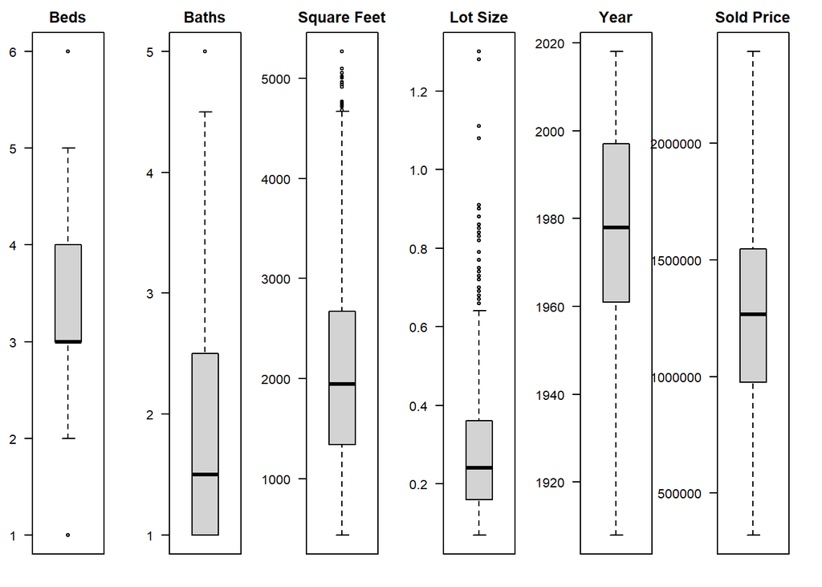

```r
par(mfrow = c(1, 6), mar = c(2, 2, 2, 2) + 0.1, las = 1)

boxplot(housing$beds, main="Beds")
boxplot(housing$baths, main="Baths")
boxplot(housing$sqft, main="Square Feet")
boxplot(housing$lotsize, main="Lot Size")
boxplot(housing$year, main="Year")
boxplot(housing$soldprice, main="Sold Price")
```

Our dataset *housing.csv* is now cleaned !Let’s move to *school.csv*.

**schools.csv EXPLORATION**

```r
schoolsData <-read.csv("schools.csv", header = T)
dim(schoolsData)
```

```
## [1] 52  3
```

```r
summary(schoolsData)
```

```
##     school               size            rating
##  Length:52          Min.   : 500.0   Min.   : 1.000
##  Class :character   1st Qu.: 700.0   1st Qu.: 4.000
##  Mode  :character   Median : 750.0   Median : 6.500
##                     Mean   : 784.6   Mean   : 6.115
##                     3rd Qu.: 862.5   3rd Qu.: 8.000
##                     Max.   :1250.0   Max.   :10.000
```

This dataset contains very few values and no NA’s.

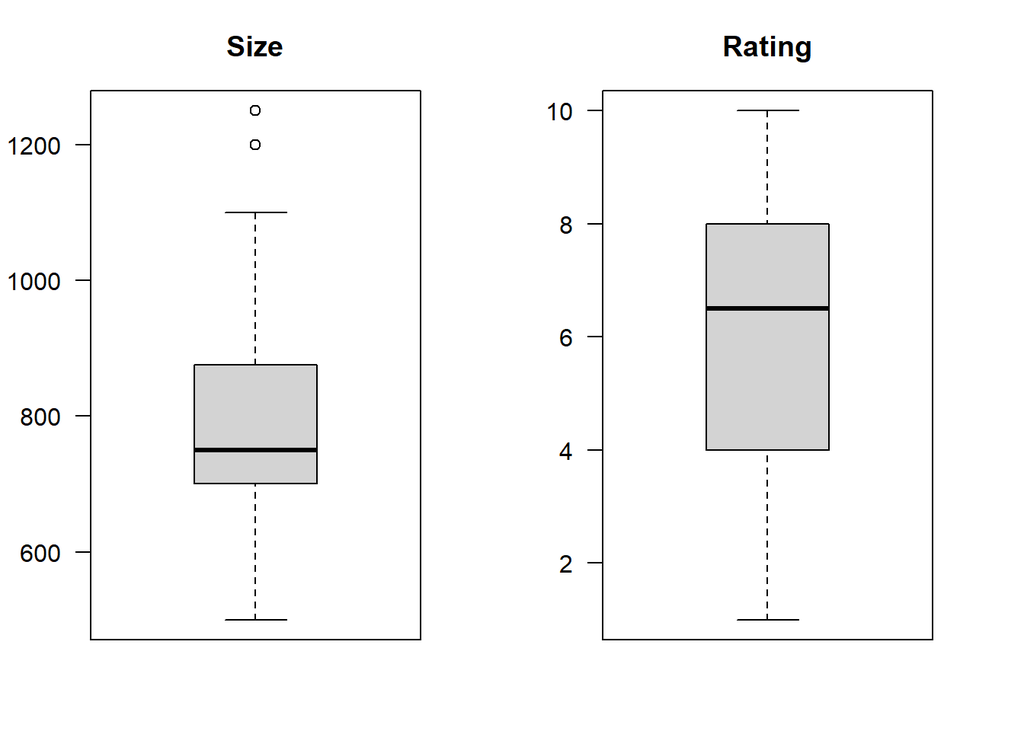

```r
par(mfrow = c(1, 2), mar = c(3, 3, 3, 3) + 0.1, las = 1)

boxplot(schoolsData$size, main="Size")
boxplot(schoolsData$rating, main="Rating")
```

In the size column, we notice some outliers which are pretty close to ‘normal’ values so nothing to worry about here.

```r
schoolsData$school <- as.factor(schoolsData$school)
table(schoolsData$school)
```

```
##
##         Alpine High          Atlas High      Avalanche High         Bear Middle
##                   1                   1                   1                   1
##   Birman Elementary       Blizzard High   Bobcat Elementary  Caracal Elementary
##                   1                   1                   1                   1
##        Channel High  Cheetah Elementary   Cougar Elementary       Coyote Middle
##                   1                   1                   1                   1
##       Crevasse High       Culpeo Middle          Delta High        Dhole Middle
##                   1                   1                   1                   1
##      Epicyon Middle          Fox Middle        Glacier High        Hound Middle
##                   1                   1                   1                   1
##        Husky Middle       Jackal Middle   Jaguar Elementary   Kodkod Elementary
##                   1                   1                   1                   1
##    Korat Elementary  Leopard Elementary     Lion Elementary     Lynx Elementary
##                   1                   1                   1                   1
##   Margay Elementary        Moraine High       Mountain High Munchkin Elementary
##                   1                   1                   1                   1
##   Ocelot Elementary   Ocicat Elementary  Oncilla Elementary        Panda Middle
##                   1                   1                   1                   1
##  Panther Elementary     Puma Elementary      Raccoon Middle         Ravine High
##                   1                   1                   1                   1
##          River High Savannah Elementary   Serval Elementary        Sloth Middle
##                   1                   1                   1                   1
##   Sphynx Elementary         Summit High    Tiger Elementary         Valley High
##                   1                   1                   1                   1
##      Vulpini Middle  Wildcat Elementary         Wolf Middle        Zorro Middle
##                   1                   1                   1                   1
```

We count 14 high schools, 15 middle schools and 23 elementary schools. Exactly the same number of each category of schools in the housing dataset.

Let’s merge the two datasets on the different categories of schools: elementary, middle and high. It will add 2 columns per category, and thus 6 columns in total.

```r
# Create new dataset
housingMerg <- housing

# Merge the housing and schools datasets based on the elementary school
housingMerg <- housingMerg %>%
  left_join(schoolsData %>% rename(elementary_rating = rating, elementary_size = size),
            by = c("elementary" = "school"))

# Merge the housing and schools datasets based on the middle school
housingMerg <- housingMerg %>%
  left_join(schoolsData %>% rename(middle_rating = rating, middle_size = size),
            by = c("middle" = "school"))

# Merge the housing and schools datasets based on the high school
housingMerg <- housingMerg %>%
  left_join(schoolsData %>% rename(high_rating = rating, high_size = size),
            by = c("high" = "school"))

# Verify the merge
summary(housingMerg)
```

```
##   neighborhood      beds           baths            sqft         lotsize
##  Orange :141   Min.   :1.000   Min.   :1.000   Min.   : 440   Min.   :0.0700
##  Blue   :136   1st Qu.:3.000   1st Qu.:1.000   1st Qu.:1342   1st Qu.:0.1600
##  Red    :116   Median :3.000   Median :1.500   Median :1948   Median :0.2400
##  Green  :102   Mean   :3.476   Mean   :1.969   Mean   :2123   Mean   :0.2879
##  Yellow : 68   3rd Qu.:4.000   3rd Qu.:2.500   3rd Qu.:2674   3rd Qu.:0.3600
##  Silver : 66   Max.   :6.000   Max.   :5.000   Max.   :5265   Max.   :1.3000
##  (Other): 54
##       year                      type         levels         cooling
##  Min.   :1908   condo             :150   Min.   :1.000   Min.   :0.0000
##  1st Qu.:1961   multi-family home : 69   1st Qu.:1.000   1st Qu.:0.0000
##  Median :1978   single-family home:333   Median :1.000   Median :0.0000
##  Mean   :1978   townhouse         :131   Mean   :1.376   Mean   :0.3294
##  3rd Qu.:1997                            3rd Qu.:2.000   3rd Qu.:1.0000
##  Max.   :2018                            Max.   :2.000   Max.   :1.0000
##
##     heating         fireplace                   elementary
##  Min.   :0.0000   Min.   :0.000   Leopard Elementary : 48
##  1st Qu.:0.0000   1st Qu.:0.000   Kodkod Elementary  : 37
##  Median :0.0000   Median :0.000   Savannah Elementary: 37
##  Mean   :0.2167   Mean   :0.325   Puma Elementary    : 36
##  3rd Qu.:0.0000   3rd Qu.:1.000   Ocicat Elementary  : 35
##  Max.   :1.0000   Max.   :1.000   Cheetah Elementary : 34
##                                   (Other)            :456
##             middle               high       soldprice       elementary_size
##  Wolf Middle   : 63   Channel High : 70   Min.   : 321000   Min.   :600.0
##  Fox Middle    : 57   Delta High   : 66   1st Qu.: 974500   1st Qu.:700.0
##  Hound Middle  : 56   Alpine High  : 58   Median :1267000   Median :750.0
##  Coyote Middle : 53   Crevasse High: 58   Mean   :1245829   Mean   :742.8
##  Sloth Middle  : 51   Glacier High : 53   3rd Qu.:1548000   3rd Qu.:800.0
##  Raccoon Middle: 48   Ravine High  : 52   Max.   :2393000   Max.   :900.0
##  (Other)       :355   (Other)      :326
##  elementary_rating  middle_size    middle_rating     high_size
##  Min.   : 1.000    Min.   :500.0   Min.   :2.000   Min.   : 750.0
##  1st Qu.: 4.000    1st Qu.:600.0   1st Qu.:5.000   1st Qu.: 850.0
##  Median : 6.000    Median :700.0   Median :7.000   Median :1000.0
##  Mean   : 5.747    Mean   :693.3   Mean   :6.179   Mean   : 967.4
##  3rd Qu.: 8.000    3rd Qu.:800.0   3rd Qu.:8.000   3rd Qu.:1100.0
##  Max.   :10.000    Max.   :900.0   Max.   :9.000   Max.   :1250.0
##
##   high_rating
##  Min.   : 1.000
##  1st Qu.: 4.000
##  Median : 6.000
##  Mean   : 5.927
##  3rd Qu.: 8.000
##  Max.   :10.000
##
```

We can move on to the next step and create graphs!

### One-Variable Visuals

*Include at least one histogram*

> Histogram of Sold Prices:

Let’s start this series of graphs with 2 histograms giving us an indication of the distribution of sales prices and the number of square feet of the houses in the dataset.

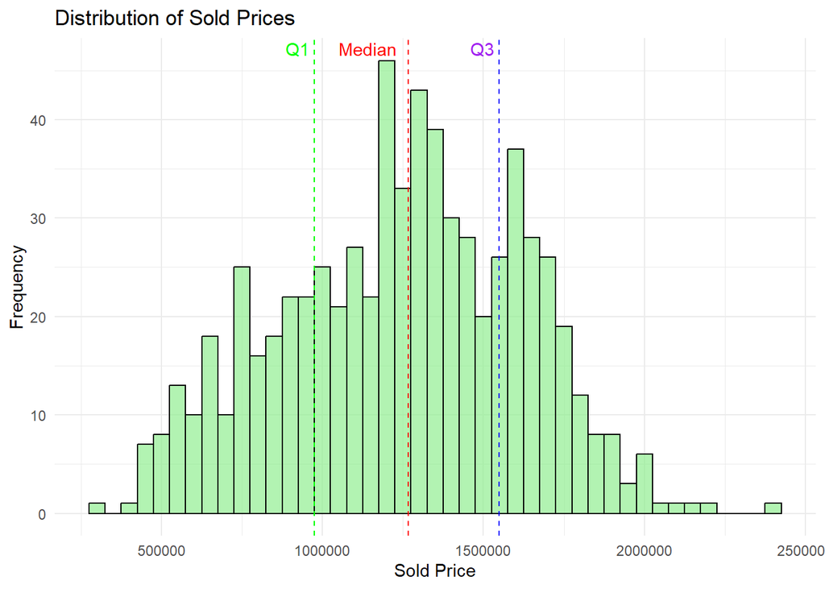

```r
# Calculate quartiles
Q1 <- quantile(housingMerg$soldprice, 0.25)
median <- median(housingMerg$soldprice)
Q3 <- quantile(housingMerg$soldprice, 0.75)

# Histogram of Sold Prices
ggplot(housingMerg, aes(x = soldprice)) +
  geom_histogram(binwidth = 50000, fill = "lightgreen", color = "black", alpha = 0.7) +
  geom_vline(xintercept = Q1, linetype = "dashed", color = "green") +
  geom_vline(xintercept = median, linetype = "dashed", color = "red") +
  geom_vline(xintercept = Q3, linetype = "dashed", color = "blue") +
  annotate("text", x = Q1, y = 46, label = "Q1", hjust = 1.2, vjust = -0.4, color = "green") +
  annotate("text", x = median, y = 46, label = "Median", hjust = 1.2, vjust = -0.4, color = "red") +
  annotate("text", x = Q3, y = 46, label = "Q3", hjust = 1.2, vjust = -0.4, color = "purple") +
  labs(title = "Distribution of Sold Prices", x = "Sold Price", y = "Frequency") +
  theme_minimal()
```

The histogram provides a visual representation of the distribution of housing prices in the dataset. It helps in identifying the most common price ranges and understanding the spread of prices across the dataset.

> Histogram of Square Feet:

Now, let’s take a look at which square feet are the most sold with the 2nd histogram showing the distribution of square feet. Like the previous graph, I’ve added the 1st quartile, median and 3rd quartile for greater precision.

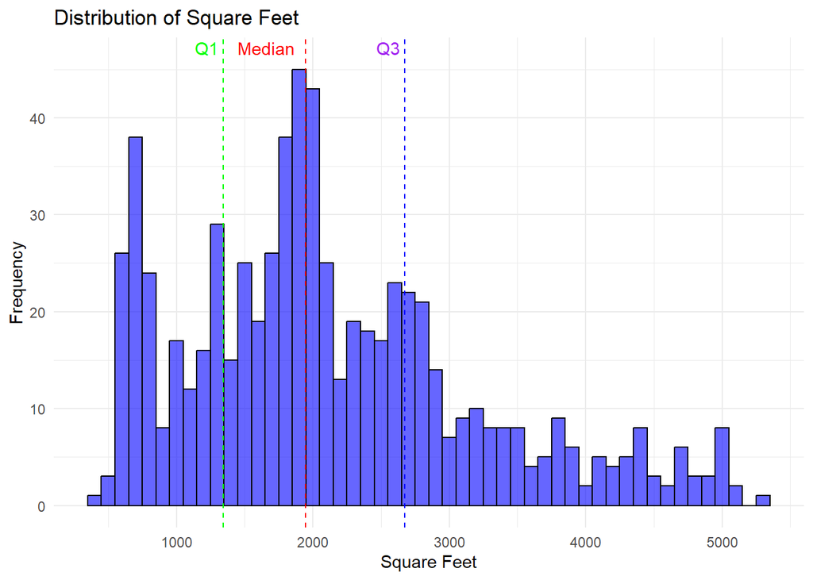

```r
# Calculate quartiles
Q1 <- quantile(housingMerg$sqft, 0.25)
median <- median(housingMerg$sqft)
Q3 <- quantile(housingMerg$sqft, 0.75)

# Histogram of Square Feet
ggplot(housingMerg, aes(x = sqft)) +
  geom_histogram(binwidth = 100, fill = "blue", color = "black", alpha = 0.6) +
  geom_vline(xintercept = Q1, linetype = "dashed", color = "green") +
  geom_vline(xintercept = median, linetype = "dashed", color = "red") +
  geom_vline(xintercept = Q3, linetype = "dashed", color = "blue") +
  annotate("text", x = Q1, y = 46, label = "Q1", hjust = 1.2, vjust = -0.4, color = "green") +
  annotate("text", x = median, y = 46, label = "Median", hjust = 1.2, vjust = -0.4, color = "red") +
  annotate("text", x = Q3, y = 46, label = "Q3", hjust = 1.2, vjust = -0.4, color = "purple") +
  labs(title = "Distribution of Square Feet", x = "Square Feet", y = "Frequency") +
  theme_minimal()
```

The distribution is a bit more balanced. Indeed, there’s a peak between Q1 and Q3, but another peak is particularly visible in the lower part of the histogram around 750 square feet: not surprising, this corresponds to the ‘condo’ and ‘condiminium’ categories of houses, i.e. apartments. It’s therefore normal to have a smaller set of surface areas than the rest.

**The majority of homes sold are between 1,500 and 2,750 square feet for houses, and around 750 square feet for apartments.**

*Include at least one bar plot*

> Bar Plot of Number of Houses Sold per Neighborhood:

Let’s continue our analysis with 2 barplots. The first shows the number of homes sold per neighborhood. Each neighborhood is categorized by color. I’ve used the associated colors for ease of reading.

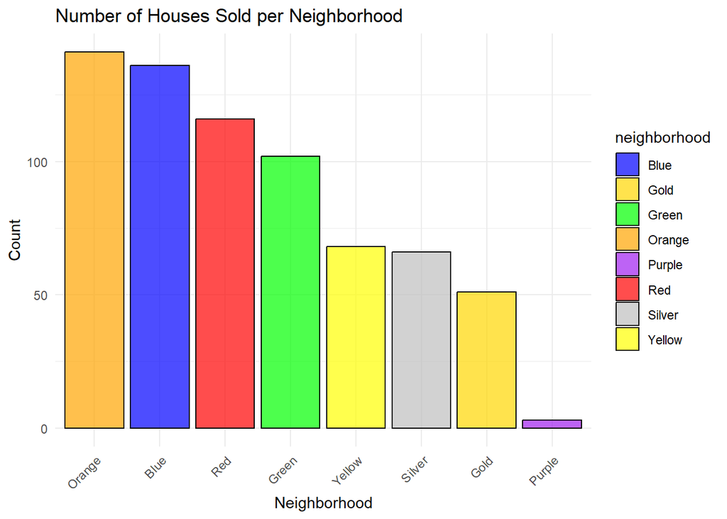

```r
# Define a named vector of colors for each neighborhood
neighborhood_colors <- c(
  "Blue" = "blue",
  "Gold" = "gold",
  "Green" = "green",
  "Orange" = "orange",
  "Purple" = "purple",
  "Red" = "red",
  "Silver" = "grey",
  "Yellow" = "yellow"
)

# Bar Plot of Number of Houses Sold per Neighborhood
ggplot(housingMerg, aes(x = reorder(neighborhood, -table(neighborhood)[neighborhood]), fill = neighborhood)) +
  geom_bar(color = "black", alpha = 0.7) +
  scale_fill_manual(values = neighborhood_colors) +
  labs(title = "Number of Houses Sold per Neighborhood", x = "Neighborhood", y = "Count") +
  theme_minimal() +
  theme(axis.text.x = element_text(angle = 45, hjust = 1))
```

The bar plot shows the count of houses sold in each neighborhood. This helps in identifying which neighborhoods have the highest and lowest sales activity. It can be useful for understanding market demand and activity in different areas.

The Orange and Blue neighborhoods are fairly close in terms of counts, but Orange remains in the lead. Next come the Red, Green, Yellow, Silver and Gold neighborhoods. The Purple district is far behind, with only 3 homes sold as seen in the summary.

**This means that the Orange, Blue and Red districts contain the most homes for sale, while the Purple district has virtually no homes for sale.**

> Bar Plot of Average School Rating by Neighborhood:

Now let’s take a look at the second barplot on the Average School Rating by neighborhood. The color of each neighborhood is preserved for better legibility and the data is sorted in descending order. The School Rating corresponds to the rating of the associated school on a scale of 0 to 10. Each neighborhood is assigned a set of schools: elementary, middle and high. We can therefore calculate the average rating by school group, and by neighborhood.

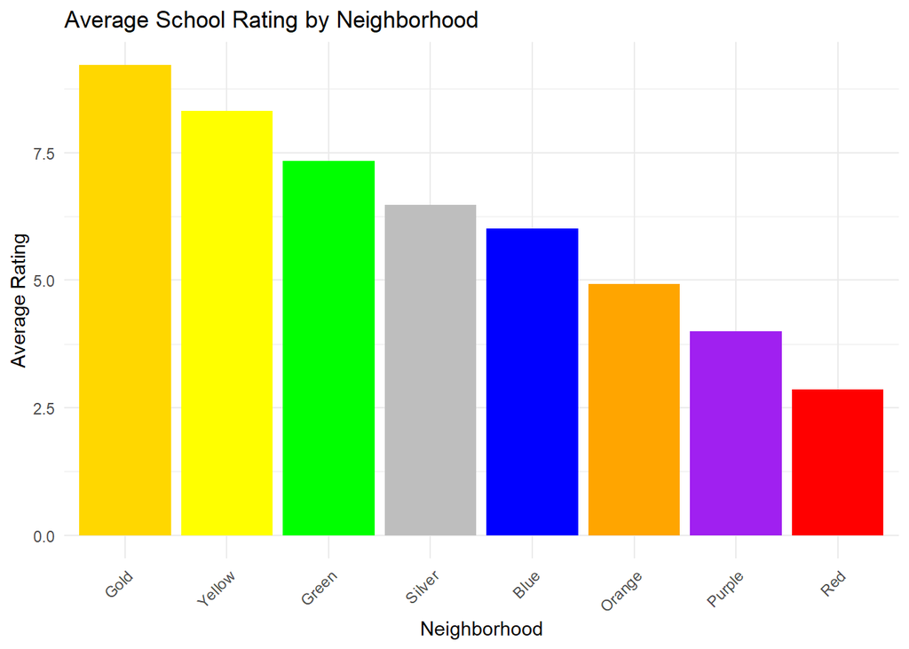

```r
# Calculate average rating for each neighborhood
avg_rating <- housingMerg %>%
  group_by(neighborhood) %>%
  summarize(avg_rating = mean(c(elementary_rating, middle_rating, high_rating), na.rm = TRUE))

# Create the bar plot with custom colors
ggplot(avg_rating, aes(x = reorder(neighborhood, -avg_rating), y = avg_rating, fill = neighborhood)) +
  geom_bar(stat = "identity", show.legend = FALSE) +
  scale_fill_manual(values = neighborhood_colors) +
  labs(title = "Average School Rating by Neighborhood", x = "Neighborhood", y = "Average Rating") +
  theme_minimal() +
  theme(axis.text.x = element_text(angle = 45, hjust = 1))
```

This bar plot shows the average school rating for each neighborhood. It combines the ratings of elementary, middle, and high schools to give an overall educational quality score for each neighborhood. This is useful for identifying areas with better educational facilities which can be attractive for families.

**We can deduce that the Gold, Yellow and Green districts can be highly prized, as they are associated with highly rated schools.**

*Include at least one Boxplot*

> Box Plot of Sold Prices by Neighborhood:

Let’s move on to the boxplots.

The first boxplot shows Sold Price by Neighborhood. Once again, the colors chosen correspond to the colors of the associated category. I’ve also added the 1st quartile, median and 3rd quartile of the sold price to better position the values. In addition, the data is sorted in descending order for easier readability.

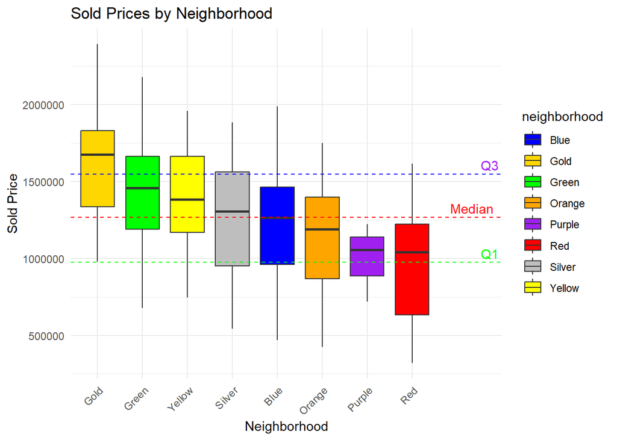

```r
# Calculate quartiles
Q1 <- quantile(housingMerg$soldprice, 0.25)
median <- median(housingMerg$soldprice)
Q3 <- quantile(housingMerg$soldprice, 0.75)

# Box Plot of Sold Prices by Neighborhood
ggplot(housingMerg, aes(x = reorder(neighborhood, -soldprice), y = soldprice, fill = neighborhood)) +
  geom_boxplot() +
  scale_fill_manual(values = neighborhood_colors) +
  geom_hline(yintercept = Q1, linetype = "dashed", color = "green") +
  geom_hline(yintercept = median, linetype = "dashed", color = "red") +
  geom_hline(yintercept = Q3, linetype = "dashed", color = "blue") +
  annotate("text", x = 10, y = Q1, label = "Q1", hjust = 1.2, vjust = -0.4, color = "green") +
  annotate("text", x = 10, y = median, label = "Median", hjust = 1.2, vjust = -0.4, color = "red") +
  annotate("text", x = 10, y = Q3, label = "Q3", hjust = 1.2, vjust = -0.4, color = "purple") +
  labs(title = "Sold Prices by Neighborhood", x = "Neighborhood", y = "Sold Price") +
  theme_minimal() +
  theme(axis.text.x = element_text(angle = 45, hjust = 1))
```

The box plot displays the distribution of housing prices for each neighborhood. It shows the median, quartiles, and potential outliers in the housing prices. This can help identify neighborhoods with higher price stability or those with high variability, which might indicate emerging or fluctuating markets.

Here, we see that the Silver and Blue districts contain 50% or more of their values between the 1st and 3rd quartile of the sale price. The district stands out from the others by having more than 50% of its values above the 3rd quartile, or above 75% of other sold prices. The Green and Yellow districts are generally equivalent, with a similar 1st and 3rd quartiles, but a slightly lower median for the Yellow district. The Purple neighborhood is the one with the least extensive values, which can be explained by the few houses in this neighborhood (3). Finally, the Red district has almost 50% of its values below the 1st quartile of the sold price, which means below 75% of the other sold prices.

> Box Plot of Sold Prices by Type of Housing Unit:

The second boxplot represents the Sold Prices by Type of Housing Unit. In fact, there are several types of accommodation (condo, multi-family home, townhouse, etc.). It is interesting to know which type of housing is the most expensive. To facilitate the positioning of the values, I again added the 1st quartile, the median and the 3rd quartile. The values are also sorted in descending order.

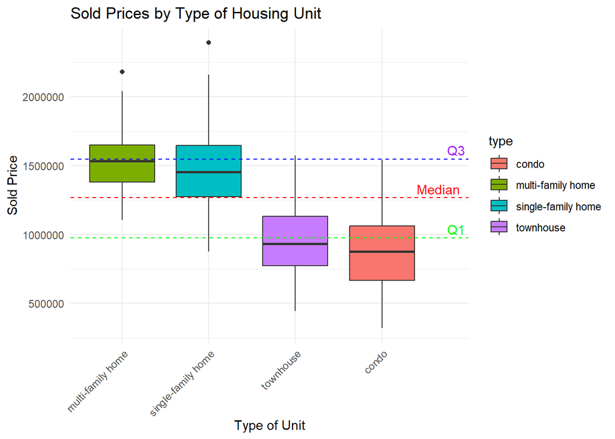

```r
# Calculate quartiles
Q1 <- quantile(housingMerg$soldprice, 0.25)
median <- median(housingMerg$soldprice)
Q3 <- quantile(housingMerg$soldprice, 0.75)

# Box Plot of Sold Prices by Type of Housing Unit
ggplot(housingMerg, aes(x = reorder(type, -soldprice), y = soldprice, fill = type)) +
  geom_boxplot() +
  geom_hline(yintercept = Q1, linetype = "dashed", color = "green") +
  geom_hline(yintercept = median, linetype = "dashed", color = "red") +
  geom_hline(yintercept = Q3, linetype = "dashed", color = "blue") +
  annotate("text", x = 5, y = Q1, label = "Q1", hjust = 1.2, vjust = -0.4, color = "green") +
  annotate("text", x = 5, y = median, label = "Median", hjust = 1.2, vjust = -0.4, color = "red") +
  annotate("text", x = 5, y = Q3, label = "Q3", hjust = 1.2, vjust = -0.4, color = "purple") +
  labs(title = "Sold Prices by Type of Housing Unit", x = "Type of Unit", y = "Sold Price") +
  theme_minimal() +
  theme(axis.text.x = element_text(angle = 45, hjust = 1))
```

The box plot displays the distribution of housing prices for different types of housing units (e.g., single-family homes, condos, townhouses). It shows the median, quartiles, and potential outliers in the prices for each type of unit. This helps in comparing the price ranges for different types of housing and can provide insights into which types of housing are more expensive or have more price variability.

From the outset, we notice that the two categories which dominate in terms of prices are multi-family home and single-family home, having part of their values above the 3rd quartile of the sold price. This type of house is undoubtedly the largest in order to accommodate large families. The other 2 categories have more than 50% of their values below the 1st quartile, or below 75% of the other sold prices.

**It is no surprise that family homes are the most expensive and condo-type housing is the most affordable, as are townhouse-type housing.**

### Two-variables visuals

*Include at least one scatter plot*

> Scatter Plot of Sold Price vs. Square Footage:

Let’s move on to scatter plot. The first scatter plot shows the relationship between the sold price of houses and their square footage. Each point represents a house, with the x-axis indicating the square footage and the y-axis indicating the sold price. This plot helps in understanding how house size influences its price and can reveal trends or patterns, such as whether larger houses tend to sell for higher prices.

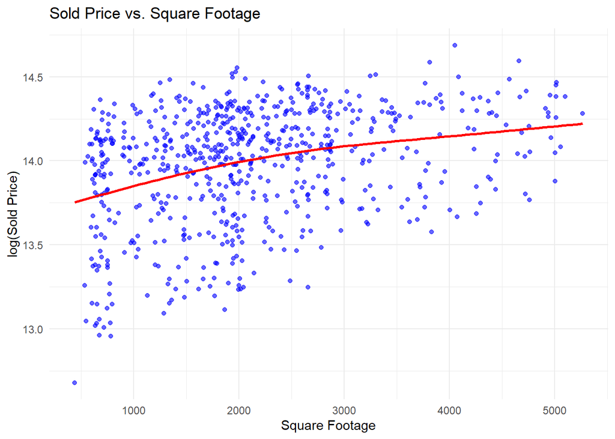

```r
# Scatter Plot of Sold Price vs. Square Footage with Smooth Spline Line
ggplot(housingMerg, aes(x = sqft, y = log(soldprice))) +
  geom_point(alpha = 0.6, color = "blue") +
  geom_smooth(method = "gam", formula = y ~ s(x, bs = "cs"), se = FALSE, color = "red") +
  labs(title = "Sold Price vs. Square Footage", x = "Square Footage", y = "log(Sold Price)") +
  theme_minimal()
```

I chose to use the logarithm to represent the sold price values. Indeed, the points are very scattered, the use of the logarithm makes it possible to bring the points together, in addition to avoiding a multitude of 0s on the y bar (due to high sold price). In addition, I drew a line to better visualize the trend of the points.

Thus, we observe a fairly significant dispersion of points with a slight trend emerging as seen with the red line. Two phases seem to be emerging:

- In the first phase, the sale price increases almost linearly for an area between 500 and 2000 square feet, going from a logarithm equal to 13.75 to 14. This represents a sale price going from 936589 to 1202604, a sold price difference of 266015 for a square feet difference of 1500.
- In the second phase, the sale price increases almost linearly for an area varying from 2000 to 5000 square feet, going from a logarithm of 14 to approximately 14.2. This represents a sale price going from 1202604 to 1468864, which mean a sold price difference of 266260 for a square feet difference of 3000.

**It would therefore seem that the more the area in square feet increases, the less the sold price increases, and the closer the prices become (wide dispersion at the beginning, and becomes finer with the increase in area)**

> Scatter Plot of Sold Price vs. Year:

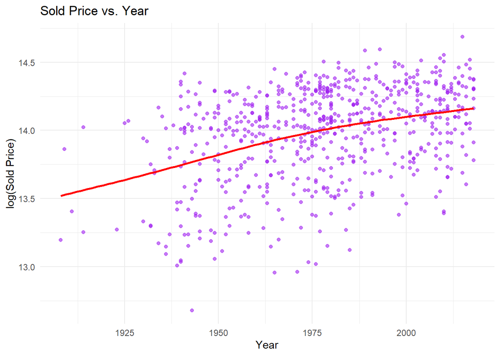

```r
# Scatter Plot of Sold Price vs. Year with Smooth Spline Line
ggplot(housingMerg, aes(x = year, y = log(soldprice))) +
  geom_point(alpha = 0.6, color = "purple") +
  geom_smooth(method = "gam", formula = y ~ s(x, bs = "cs"), se = FALSE, color = "red") +
  labs(title = "Sold Price vs. Year", x = "Year", y = "log(Sold Price)") +
  theme_minimal()
```

In short, until 1975, the year the house was built seemed to significantly increase the price of housing. After 1975, the increase in the sold price was lower.

*Include at least one high density plot*

> Density Plot of Sold Prices by Number of Bedrooms:

The density plot shows the distribution of sold prices for houses with different numbers of bedrooms. Each line represents the distribution of sold prices for houses with a specific number of bedrooms. This plot helps in comparing the price distributions across houses with different bedroom counts, identifying which bedroom categories have higher or lower price ranges, and understanding the price density.

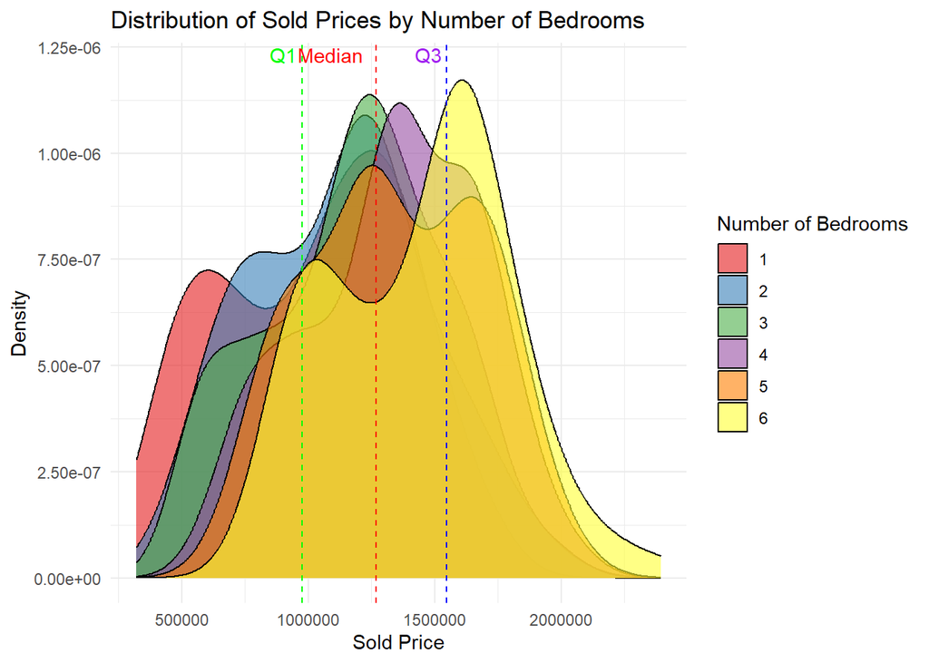

```r
# Calculate quartiles
Q1 <- quantile(housingMerg$soldprice, 0.25)
median <- median(housingMerg$soldprice)
Q3 <- quantile(housingMerg$soldprice, 0.75)

# Density Plot of Sold Prices by Number of Bedrooms
ggplot(housingMerg, aes(x = soldprice, fill = factor(beds))) +
  geom_density(alpha = 0.6) +
  geom_vline(xintercept = Q1, linetype = "dashed", color = "green") +
  geom_vline(xintercept = median, linetype = "dashed", color = "red") +
  geom_vline(xintercept = Q3, linetype = "dashed", color = "blue") +
  annotate("text", x = Q1, y = 1.2e-06, label = "Q1", hjust = 1.2, vjust = -0.4, color = "green") +
  annotate("text", x = median, y = 1.2e-06, label = "Median", hjust = 1.2, vjust = -0.4, color = "red") +
  annotate("text", x = Q3, y = 1.2e-06, label = "Q3", hjust = 1.2, vjust = -0.4, color = "purple") +
  labs(title = "Distribution of Sold Prices by Number of Bedrooms", x = "Sold Price", y = "Density", fill = "Number of Bedrooms") +
  theme_minimal() +
  scale_fill_brewer(palette = "Set1")
```

A 6 bedrooms housing is way more expensive than a 1 bedroom housing.